# Clase 3

Pachá

June 30, 2016

# Modelo de Regresión Básico

- Mínimos cuadrados es una herramienta de estimación.
- Para realizar inferencia se desarrolla un modelo probabilístico de regresión lineal
  $$Y_i = \beta_0 + \beta_1 X_i + \varepsilon_{i}$$
- Aquí $\varepsilon_{i}$ se asume iid $N(0, \sigma^2)$.
- Note que $E[Y_i ~|~ X_i = x_i] = \mu_i = \beta_0 + \beta_1 x_i$
- Note que $Var(Y_i ~|~ X_i = x_i) = \sigma^2$.
- La estimación por ML de $\beta_0$ y $\beta_1$ coincide con la estimación por OLS
  $$\hat \beta_1 = Cor(Y, X) \frac{Sd(Y)}{Sd(X)} ~~~ \hat \beta_0 = \bar Y - \hat \beta_1 \bar X$$
- $E[Y ~|~ X = x] = \beta_0 + \beta_1 x$
- $Var(Y ~|~ X = x) = \sigma^2$

# Interpretación de los coeficientes

## Intercepto

- $\beta_0$ es el valor esperado del output cuando el input es 0
  $$E[Y | X = 0] = \beta_0 + \beta_1 \times 0 = \beta_0$$
- Note que esto no siempre es de interés, por ejemplo cuando $X=0$ es imposible o está fuera del rango de los datos (e.g. Si $X$ corresponde a presión sanguínea, estatura, etc.)
- Considere que
  $$Y_i = \beta_0 + \beta_1 X_i + \varepsilon_i
  = \beta_0 + a \beta_1 + \beta_1 (X_i - a) + \varepsilon_i
  = \tilde \beta_0 + \beta_1 (X_i - a) + \varepsilon_i$$
  Entonces, si desplazamos $X$ en $a$ unidades cambia el intercepto pero no la pendiente. menudo $a$ se fija en $\bar X$ tal que el intercepto se interpreta como la respuesta esperada en el valor promedio de $X$.

## Pendiente

- $\beta_1$ es el cambio esperado en el output cuando el input cambia en una unidad
  $$E[Y ~|~ X = x+1] - E[Y ~|~ X = x] =
  \beta_0 + \beta_1 (x + 1) - (\beta_0 + \beta_1 x ) = \beta_1$$
- Considere el impacto de cambiar las unidades (medición) de $X$
  $$Y_i = \beta_0 + \beta_1 X_i + \varepsilon_i
  = \beta_0 + \frac{\beta_1}{a} (X_i a) + \varepsilon_i
  = \beta_0 + \tilde \beta_1 (X_i a) + \varepsilon_i$$
- Entonces, la multiplicación de $X$ por un factor $a$ resulta en que se divide el coeficiente por el mismo factor $a$.
- Si queremos predecir el output dado un valor del input, digamos $X$, el modelo de regresión predice
  $$\hat \beta_0 + \hat \beta_1 X$$

## Ejemplo

- Si $X$ es la estatura en $m$ e $Y$ es el peso en $kg$. Entonces $\beta_1$ es $kg/m$. Convirtiendo $X$ en $cm$ implica multiplicar $X$ por $100 cm/m$. Para obtener $\beta_1$ en las unidades correctas, tenemos que dividir por $100 cm /m$ y así se tendrán las unidades correctas.
  $$X m \times \frac{100cm}{m} = (100 X) cm
  ~~\mbox{y}~~
  \beta_1 \frac{kg}{m} \times\frac{1 m}{100cm} =
  \left(\frac{\beta_1}{100}\right)\frac{kg}{cm}$$

# Modelo Lineal Univariado

## Los Datos de Galton

Francis Galton (1882 - 1911) sentó las bases de la Econometría estudiando la estatura de padres e hijos. Los datos de su estudio están disponibles en la instalación de R. El gráfico de estatura de padres versus estatura de hijos es el siguiente:

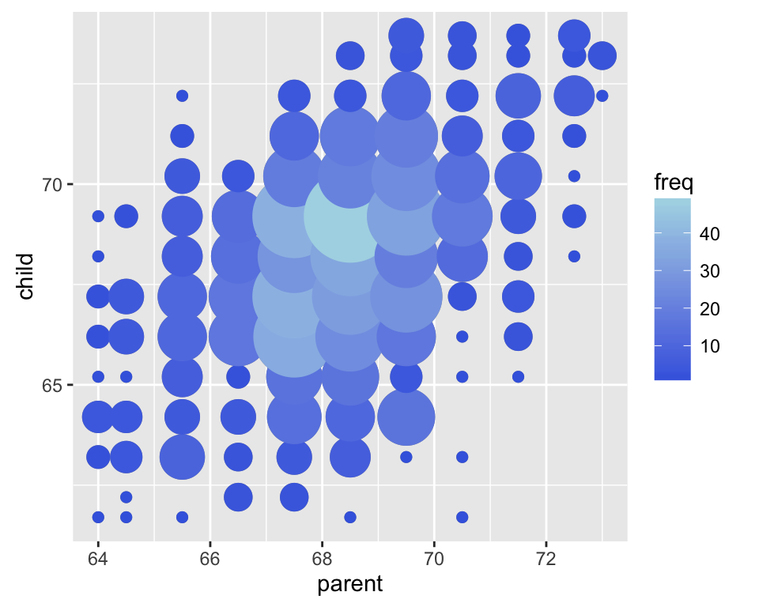

## Ejercicios

- Usar la estatura de los padres para predecir la de los hijos
- Encontrar una relación entre ambas estaturas
- Encontrar la variación de la estatura de los hijos que no depende de la estatura de los padres (variación residual)
- Los supuestos que se necesitan para generalizar más allá de los datos
- Por qué los hijos de padres muy altos tienden a ser más bajos (regresión a la media)

## Análisis de los datos

- Datos recolectados y analizados por Francis Galton en 1885.
- Galton fue un científico que creó los conceptos de correlación y regresión.
- Veremos la distribución marginal de los datos.
- La corrección por género se obtiene multiplicando la estatura de las mujeres por 1,08.

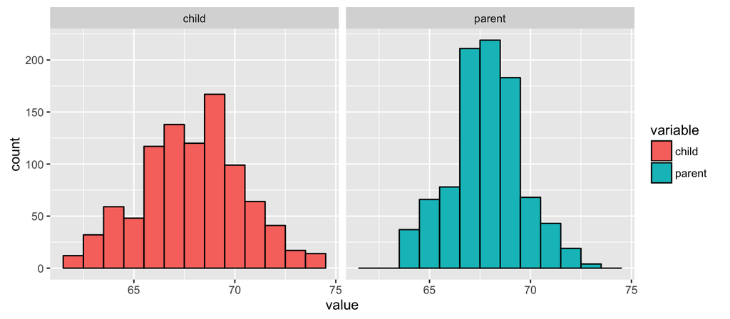

```r
library(reshape); long <- melt(galton)
g <- ggplot(long, aes(x = value, fill = variable))
g <- g + geom_histogram(colour = "black", binwidth=1)
g <- g + facet_grid(. ~ variable)
g
```